# Week 3

Keaan Amin

20 February 2021

## Welcome Back

- R Basics and Graphical projection [Week 1]
- Building our Classification Models top to toe [Week 2]
- Looping, Statistical Testing [Week 2]

## This Week

- Can we Classify Liver Disease Patients using Blood Test Results.
- Optimise models - hyperparameters.
- What further cross-validation methods might be of added benefit.

## Setup

```r
head(df)
```

```
##   Age Gender Total_Bilirubin Direct_Bilirubin Alkaline_Phosphotase
## 1  65 Female             0.7              0.1                  187
## 2  62   Male            10.9              5.5                  699
## 3  62   Male             7.3              4.1                  490
## 4  58   Male             1.0              0.4                  182
## 5  72   Male             3.9              2.0                  195
## 6  46   Male             1.8              0.7                  208
##   Alamine_Aminotransferase Aspartate_Aminotransferase Total_Protiens Albumin
## 1                       16                         18            6.8     3.3
## 2                       64                        100            7.5     3.2
## 3                       60                         68            7.0     3.3
## 4                       14                         20            6.8     3.4
## 5                       27                         59            7.3     2.4
## 6                       19                         14            7.6     4.4
##   Albumin_and_Globulin_Ratio Dataset
## 1                       0.90       1
## 2                       0.74       1
## 3                       0.89       1
## 4                       1.00       1
## 5                       0.40       1
## 6                       1.30       1
```

```r
df <- df[ , colSums(is.na(df)) == 0]
pdata <- df[drop=FALSE,,colnames(df) %in% c("Age","Gender","Dataset")]
```

## Phenotypic Data

- Power of what we know is in the phenotype.

```r
pdata$diagnosis <- as.character(df$Dataset)
pdata$diagnosis <- ifelse(pdata$diagnosis=="1","Disease",pdata$diagnosis)
pdata$diagnosis <- ifelse(pdata$diagnosis=="2","Normal",pdata$diagnosis)
head(pdata)
```

```
##   Age Gender Dataset diagnosis
## 1  65 Female       1   Disease
## 2  62   Male       1   Disease
## 3  62   Male       1   Disease
## 4  58   Male       1   Disease
## 5  72   Male       1   Disease
## 6  46   Male       1   Disease
```

```r
###dataset of just integers and without pdata
dfint <- df[,!colnames(df) %in% c("Age","Gender","Dataset")]
```

## Data Processing

- Can we project anything to suggest that our data might separate the two groups

```r
cormat <- round(cor(dfint),2)

library(reshape2)
melted_cormat <- melt(cormat)
head(melted_cormat)
```

```
##                         Var1            Var2 value
## 1            Total_Bilirubin Total_Bilirubin  1.00
## 2           Direct_Bilirubin Total_Bilirubin  0.87
## 3       Alkaline_Phosphotase Total_Bilirubin  0.21
## 4   Alamine_Aminotransferase Total_Bilirubin  0.21
## 5 Aspartate_Aminotransferase Total_Bilirubin  0.24
## 6             Total_Protiens Total_Bilirubin -0.01
```

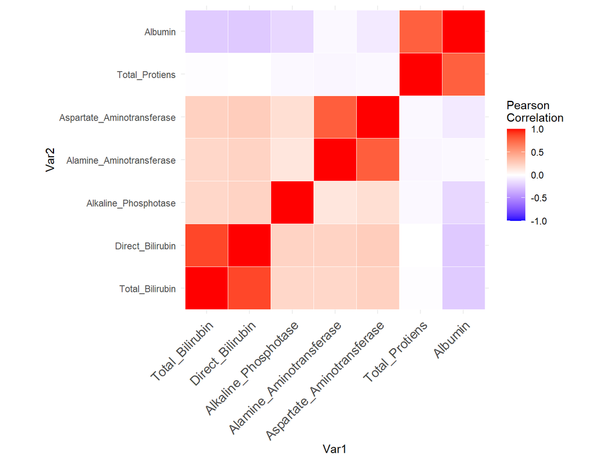

```r
library(ggplot2)
ggplot(data = melted_cormat, aes(x=Var1, y=Var2, fill=value))+
  geom_tile(color = "white")+
  scale_fill_gradient2(low = "blue", high = "red", mid = "white",
                       midpoint = 0, limit = c(-1,1), space = "Lab",
                       name="Pearson\nCorrelation") +
  theme_minimal()+
  theme(axis.text.x = element_text(angle = 45, vjust = 1,
                                   size = 12, hjust = 1))+
  coord_fixed()
```

- It appears that we have some correlated variables, consistent with what we expected.
- Important to capture both as to avoid not keeping dependent details to explain variability in the two groups

## BONUS - Principal Components

```r
pcas <- prcomp(dfint,scale=TRUE,center=TRUE)
str(pcas)
```

```
## List of 5
##  $ sdev    : num [1:7] 1.586 1.31 1.167 0.945 0.476 ...
##  $ rotation: num [1:7, 1:7] 0.487 0.497 0.258 0.394 0.415 ...
##   ..- attr(*, "dimnames")=List of 2
##   .. ..$ : chr [1:7] "Total_Bilirubin" "Direct_Bilirubin" "Alkaline_Phosphotase" "Alamine_Aminotransferase" ...
##   .. ..$ : chr [1:7] "PC1" "PC2" "PC3" "PC4" ...
##  $ center  : Named num [1:7] 3.3 1.49 290.58 80.71 109.91 ...
##   ..- attr(*, "names")= chr [1:7] "Total_Bilirubin" "Direct_Bilirubin" "Alkaline_Phosphotase" "Alamine_Aminotransferase" ...
##  $ scale   : Named num [1:7] 6.21 2.81 242.94 182.62 288.92 ...
##   ..- attr(*, "names")= chr [1:7] "Total_Bilirubin" "Direct_Bilirubin" "Alkaline_Phosphotase" "Alamine_Aminotransferase" ...
##  $ x       : num [1:583, 1:7] -0.9427 1.4996 0.7383 -0.9103 -0.0094 ...
##   ..- attr(*, "dimnames")=List of 2
##   .. ..$ : NULL
##   .. ..$ : chr [1:7] "PC1" "PC2" "PC3" "PC4" ...
##  - attr(*, "class")= chr "prcomp"
```

```r
pcasdf <-data.frame(pcas$x)
head(pcasdf)
```

```
##            PC1         PC2         PC3         PC4         PC5         PC6
## 1 -0.942691459 -0.05615804 -0.03123308 -0.17383935 -0.12493574  0.09798186
## 2  1.499565344 -0.83172535  1.67240452  1.20977474 -0.08711205  0.21020773
## 3  0.738301405 -0.48894451  1.05889704  0.55542105  0.06434639  0.03734170
## 4 -0.910318433 -0.14664813  0.04927807 -0.21878081 -0.08041337  0.01310869
## 5 -0.009395447  0.19693188  0.43989841 -0.34801365 -0.72735966  0.92832182
## 6 -1.272380086 -1.44148882  0.44221645 -0.07831981  0.17914583 -0.32369245
##            PC7
## 1  0.061378502
## 2 -0.084507216
## 3 -0.189607800
## 4  0.004691639
## 5  0.082232288
## 6 -0.032166883
```

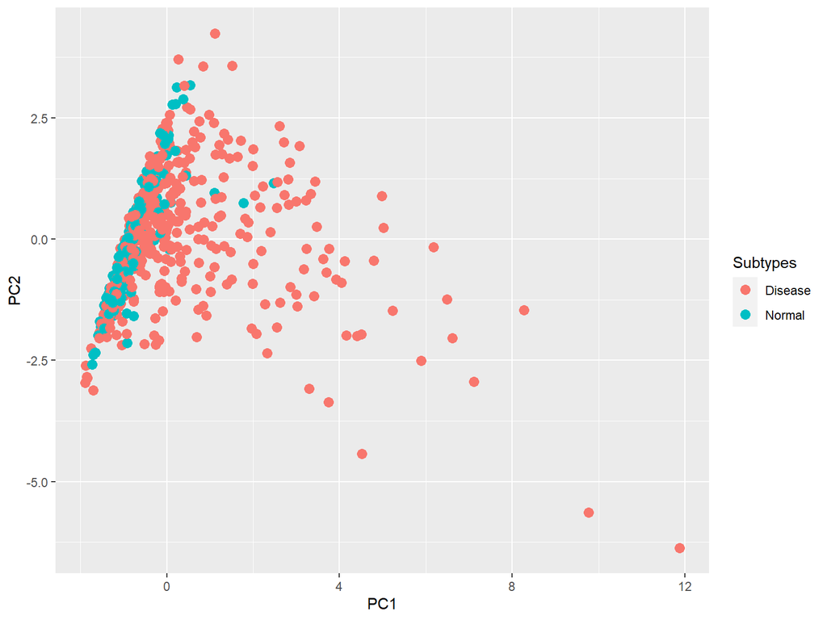

```r
require(ggplot2)
ggplot(pcasdf,aes(x=PC1,y=PC2,col=pdata$diagnosis))+
  labs(color = "Subtypes") +
  geom_point(size=3)
```

- As perhaps expected there appears to be a greater amount of variance in our diseased samples.
- As suggested here, the differences in many samples are no clear. May well be the plot itself not providing enough resolution on these two axes.
- Let’s still go ahead and see.

## Lets plot the differences across our variables

```r
df_filt <- df[, colnames(df) %in% c("Direct_Bilirubin","Total_Bilirubin","Alkaline_Phosphotase","Alamine_Aminotransferase","Aspartate_Aminotransferase","Total_Protiens",
                                    "Albumin")]
df_filt$diagnosis <- pdata$diagnosis
require(caret)
```

```r
plot.new()
```

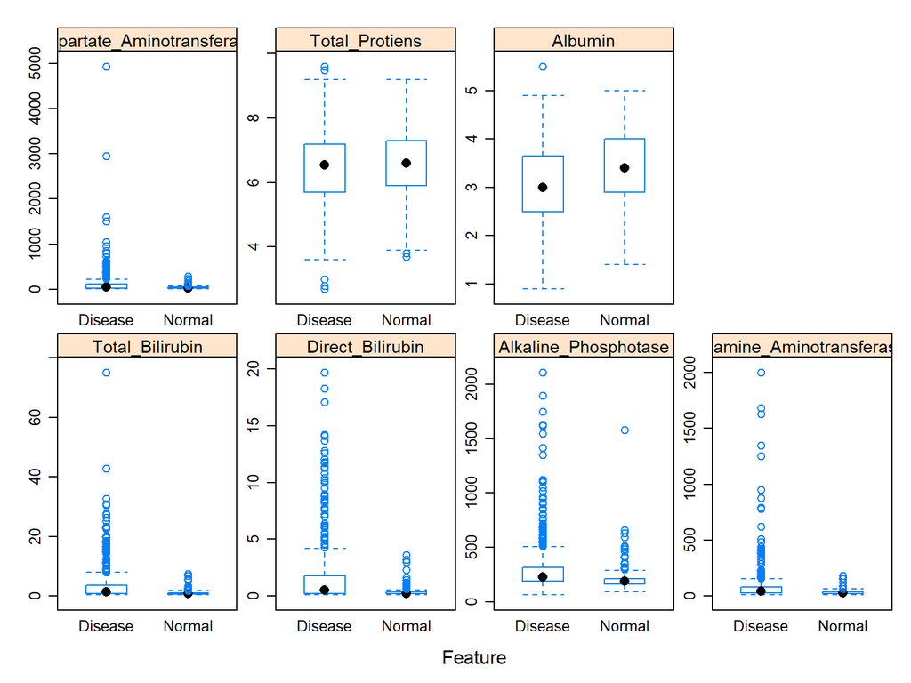

```r
featurePlot(x = df_filt[, 1:7],
            y = as.factor(pdata$diagnosis),
            plot = "box",
            strip=strip.custom(par.strip.text=list(cex=.9)),
            scales = list(x = list(relation="free"),
                          y = list(relation="free")))
```

## Create our Datasets

```r
# Create the training and test datasets
set.seed(100)
library(nnet)
require("e1071")
## install.packages("caretEnsemble")
require(caretEnsemble)
# Step 1: Get row numbers for the training data
trainRowNumbers <- createDataPartition(pdata$Dataset, p=0.8, list=FALSE)

# Step 2: Create the training  dataset
trainData <- df_filt[trainRowNumbers,]

# Step 3: Create the test dataset
testData <- df_filt[-trainRowNumbers,]
```

```r
##Lets make Cross-validation 10x as our control
control <- trainControl(method="cv", number=10)

##Assess performance by ROC
metric <- "ROC"
```

## Lets Train and Test

```r
set.seed(65)
results <- train(diagnosis~., data=trainData, method="rf", metric="ROC",
                 trControl = trainControl(method = "cv", number = 10,classProbs=TRUE,summaryFunction = twoClassSummary, savePredictions = T))

## Lets evaluate more than one model
alg_list <- c("rf", "glm", "gbm", "lda", "rpart", "nnet","svmRadial","knn")
set.seed(65)
?caretList
```

```
## starting httpd help server ... done
```

```r
resultsList <- caretList(diagnosis~ ., data=trainData,methodList = alg_list,metric="ROC",
          trControl = trainControl(method = "cv", number = 10,classProbs=TRUE,summaryFunction = twoClassSummary,
                                   savePredictions = T))
resListdata <- resamples(resultsList)
?resamples
resListdata$values
```

```
##    Resample    rf~ROC   rf~Sens    rf~Spec   glm~ROC  glm~Sens   glm~Spec
## 1    Fold01 0.7386878 0.9117647 0.23076923 0.7239819 0.9117647 0.15384615
## 2    Fold02 0.7657343 0.8181818 0.53846154 0.7156177 0.8787879 0.30769231
## 3    Fold03 0.8009050 0.9411765 0.23076923 0.7352941 0.9411765 0.15384615
## 4    Fold04 0.6806527 0.7575758 0.30769231 0.7785548 0.9696970 0.07692308
## 5    Fold05 0.7895928 0.9411765 0.38461538 0.7149321 0.8529412 0.23076923
## 6    Fold06 0.8110860 0.8235294 0.38461538 0.8190045 0.9117647 0.07692308
## 7    Fold07 0.7364253 0.8529412 0.30769231 0.7149321 0.9705882 0.15384615
## 8    Fold08 0.7364253 0.9411765 0.15384615 0.7556561 0.9117647 0.15384615
## 9    Fold09 0.7167832 0.9090909 0.07692308 0.7296037 0.9696970 0.15384615
## 10   Fold10 0.6385281 0.9090909 0.14285714 0.7705628 0.9696970 0.28571429
##      gbm~ROC  gbm~Sens  gbm~Spec   lda~ROC  lda~Sens   lda~Spec rpart~ROC
## 1  0.6787330 0.8529412 0.2307692 0.7330317 0.9705882 0.15384615 0.6323529
## 2  0.7319347 0.8484848 0.3846154 0.6643357 1.0000000 0.00000000 0.6340326
## 3  0.7963801 0.9411765 0.2307692 0.6719457 0.9705882 0.15384615 0.7307692
```

[output cut: 29 more lines]

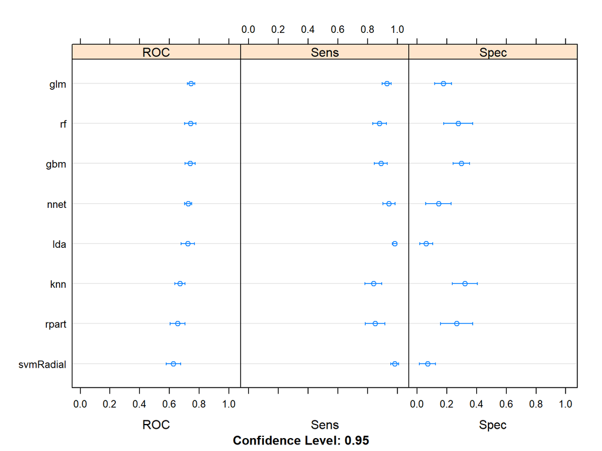

```r
dotplot(resListdata)
```

```r
## Lets see how our best performing model does on validation.
predictions <- predict(resultsList$glm,testData)
results<- confusionMatrix(predictions,as.factor(testData$diagnosis), positive="Disease")
```

[output not shown]

## Lets save our best performing model

```r
saveRDS(resultsList$glm, "liver_disease_model.RDS")
```

- We can load this back into R by

```r
getwd()
```

```
## [1] "C:/Users/keaan/Documents/KeaanData/My Scripts"
```

```r
list.files()
```

[output not shown]

[output cut: 161 more lines]

```r
liver_model <- readRDS("liver_disease_model.RDS")
```

## How can we improve what we have?

- More Aggressive Feature Selection [can we capture what we have from less and how can we weight that]
- Tuning our Parameters [Grid searching, Random searching, Bayesian testing, advanced mathematical functioning]